# Prueba

## 1. Introducción

## 2.Carga de librerías.

A continuación, se muestran las librerías que se utilizarán a lo largo del cuaderno. En caso de no disponer de alguna de ellas, ejecute el comando install.packages(““).

```r
library(readr)
library(GenomicRanges)
library(dplyr)
library(tidyr)
library(data.table)
library(ggplot2)
library(cowplot)
library(RColorBrewer)
library(grid)
library(forcats)
library(DESeq2)
library(biomaRt)
```

## 3.Carga de datos.

En esta sección, cargamos los datos de la expresión para distintas muestras obtenidos con RNAseq crudos y procesados utilizando TPM. Además, añadimos un archivo de metadatos donde se registra información de cada una de las muestras.

```r
message("Cargando datos...")
```

```
Cargando datos...
```

```r
exp_tpm <- fread("~/Monocitos_Macrofagos/Data/genes_tpm_monomacro_processed.csv.gz")
meta_datos <- fread("~/Monocitos_Macrofagos/Data/metadata_monomacro_filtered.csv.gz")
exp_raw <- fread("~/Monocitos_Macrofagos/Data/genes_expected_count_DESeq2.csv.gz")
```

## 4.Filtrado de datos y matriz de expresión.

Vamos a realizar un filtrado de los datos de las TPM para calcular la PCA y ver que muestras nos interesan. En este ejemplo, nos vamos a centrar en los macrófagos

```r
macrophage_meta <- meta_datos %>%
  filter(harmonized_sample_label == "Macrophage") %>%
  mutate(across(where(is.character), as.factor))

message("Preparando matriz de expresión...")
```

```
Preparando matriz de expresión...
```

```r
common_samples <- intersect(macrophage_meta$EpiRR, colnames(exp_tpm))

expr_matrix_raw <- exp_tpm %>%
  dplyr::select(id_col, all_of(common_samples))

macrophage_meta_filtered <- macrophage_meta %>%
  filter(EpiRR %in% common_samples) %>%
  arrange(match(EpiRR, common_samples))

expr_matrix <- as.data.frame(expr_matrix_raw)
rownames(expr_matrix) <- expr_matrix$id_col
expr_matrix <- expr_matrix[, -1]
expr_matrix <- as.matrix(expr_matrix)

expr_t <- t(expr_matrix)

if (!all(rownames(expr_t) == macrophage_meta_filtered$EpiRR)) {
  stop("El orden de las muestras en la matriz de expresión y los metadatos no coincide. ¡Deteniendo!")
} else {
  message("Las muestras en la matriz de expresión y los metadatos están correctamente alineadas.")
}
```

```
Las muestras en la matriz de expresión y los metadatos están correctamente alineadas.
```

## 5.Cálculo de PCA

```r
message("Realizando cálculo de PCA...")
```

```
Realizando cálculo de PCA...
```

```r
pca_res <- prcomp(expr_t, center = TRUE, scale. = FALSE)
var_exp <- (pca_res$sdev^2) / sum(pca_res$sdev^2)

pca_df_base <- data.frame(
  sample = rownames(pca_res$x),
  PC1 = pca_res$x[,1],
  PC2 = pca_res$x[,2])
```

## 6.Representación de la PCA para cada metadato

```r
generate_pca_plot_core <- function(pca_data_frame, metadata_df, color_column,
                                   title_prefix = "",
                                   point_size = 3, label_points = FALSE,
                                   colors_palette = NULL,
                                   show_legend_for_extraction = FALSE) {

  pca_df_final <- pca_data_frame %>%
    dplyr::left_join(metadata_df %>% dplyr::select(EpiRR, !!sym(color_column)),
                     by = c("sample" = "EpiRR")) %>%
    dplyr::mutate(color_group = .data[[color_column]])

  pc1_var_exp <- round(100 * var_exp[1], 1)
  pc2_var_exp <- round(100 * var_exp[2], 1)

  p <- ggplot(pca_df_final, aes(x = PC1, y = PC2, color = color_group)) +
    geom_point(size = point_size) +
    labs(
      title = paste0(title_prefix, "PCA por ", gsub("_", " ", color_column)),
      x = paste0("PC1 (", pc1_var_exp, "%)"),
      y = paste0("PC2 (", pc2_var_exp, "%)"),
      color = gsub("_", " ", color_column)
    ) +
    theme_minimal() +
    theme(
      plot.title = element_text(hjust = 0.5, face = "bold"),
      legend.position = if (show_legend_for_extraction) "bottom" else "none",
      legend.justification = "center",
      legend.text = element_text(size = 6),
      legend.title = element_text(size = 7, face = "bold")
    )

  if (label_points) {
    p <- p + geom_text(aes(label = sample), size = 2.5, vjust = -1, show.legend = FALSE)
  }

  if (!is.null(colors_palette)) {
    p <- p + scale_color_manual(values = colors_palette)
  }

  return(p)
}

# --- 6. Seleccionar columnas del metadata para colorear ---
message("Identificando columnas adecuadas para colorear los plots...")
```

```
Identificando columnas adecuadas para colorear los plots...
```

```r
excluded_cols_manual <- c("EpiRR", "harmonized_sample_label", "id_col")

columns_to_plot_by <- macrophage_meta_filtered %>%
  dplyr::select(-any_of(excluded_cols_manual)) %>%
  colnames()

if (length(columns_to_plot_by) == 0) {
  warning("No se encontraron columnas categóricas adecuadas en los metadatos para generar plots.")
} else {
  message(paste(
    "Se generarán plots para las siguientes columnas:",
    paste(columns_to_plot_by, collapse = ", ")
  ))
}
```

[output not shown]

[output not shown]

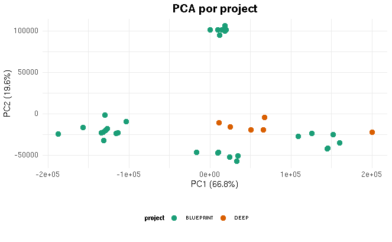

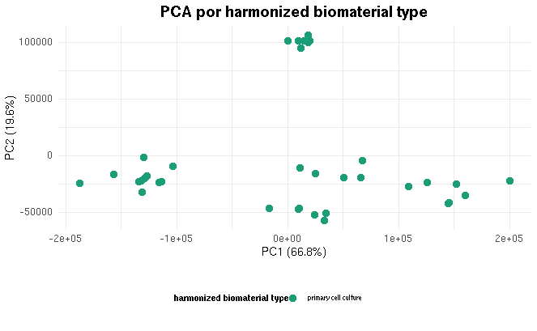

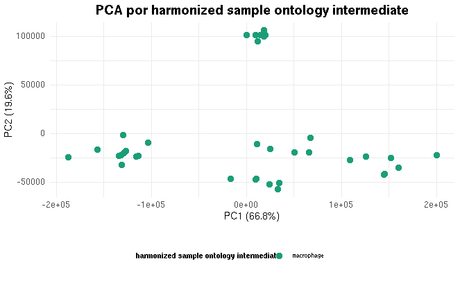

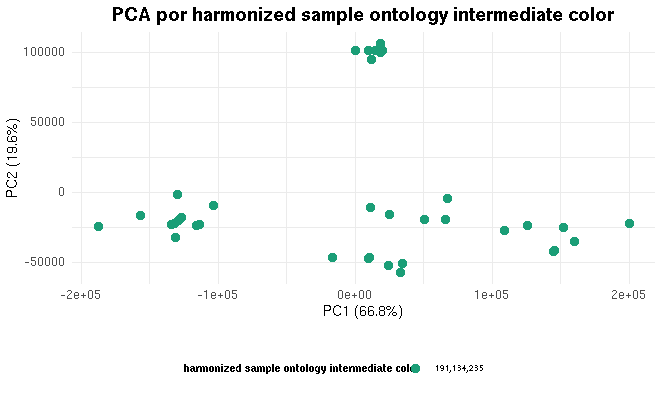

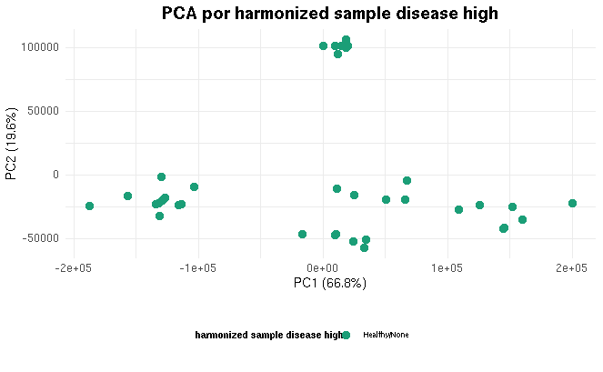

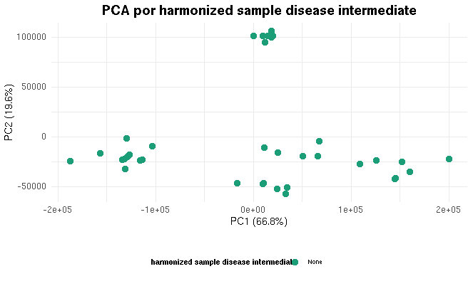

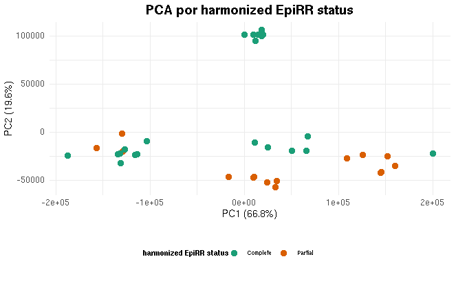

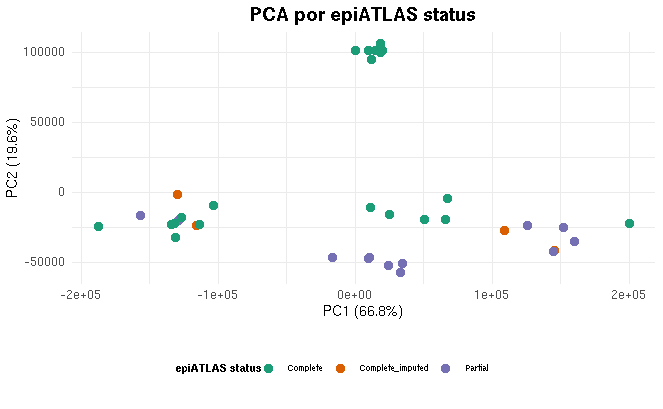

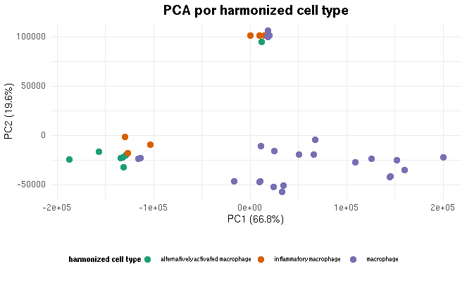

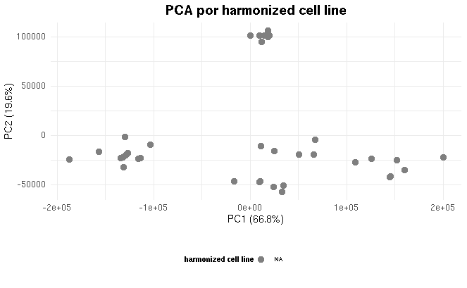

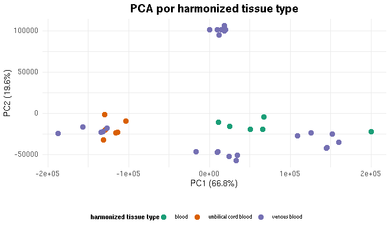

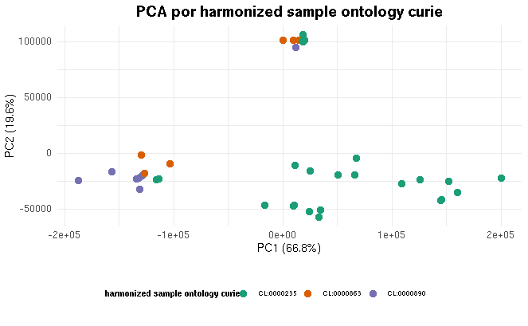

[40 more figures not shown]

```r
# --- 7. Crear los plots y mostrarlos en el cuaderno ---
composed_plots_list <- list()

if (length(columns_to_plot_by) > 0) {

  message("Mostrando plots directamente en el cuaderno...")

  for (col_name in columns_to_plot_by) {
    message(paste("Procesando columna:", col_name))

    macrophage_meta_filtered[[col_name]] <- as.factor(macrophage_meta_filtered[[col_name]])
    num_levels <- nlevels(macrophage_meta_filtered[[col_name]])

    # Paletas automáticas según número de categorías
    if (num_levels <= 8) {
      current_colors <- RColorBrewer::brewer.pal(max(3, num_levels), "Dark2")[1:num_levels]
    } else if (num_levels <= 12) {
      current_colors <- RColorBrewer::brewer.pal(max(3, num_levels), "Paired")[1:num_levels]
    } else {
      current_colors <- grDevices::colorRampPalette(
        RColorBrewer::brewer.pal(9, "Set1")
      )(num_levels)
    }

    # Plot para extraer leyenda
    plot_for_legend <- generate_pca_plot_core(
      pca_data_frame = pca_df_base,
      metadata_df = macrophage_meta_filtered,
      color_column = col_name,
      point_size = 2.5,
      colors_palette = current_colors,
      show_legend_for_extraction = TRUE
    )

    legend_plot <- get_legend(plot_for_legend)

    # Plot principal
    main_plot <- generate_pca_plot_core(
      pca_data_frame = pca_df_base,
      metadata_df = macrophage_meta_filtered,
      color_column = col_name,
      point_size = 2.5,
      colors_palette = current_colors,
      show_legend_for_extraction = FALSE
    )

    # Composición final
    composed_plot <- plot_grid(
      main_plot, legend_plot,
      ncol = 1,
      rel_heights = c(0.8, 0.2),
      align = "v"
    )

    composed_plots_list[[col_name]] <- composed_plot

    print(composed_plot)
  }

  message("✅ Proceso completado. Gráficos generados en el cuaderno.")

} else {
  message("⚠️ No se generaron plots por falta de columnas válidas.")
}
```

```r
NA
```

## 7.Filtrado de datos

Después de observar las PCAs, selecionamos el grupo de datos que nos interesa. En nuestro caso, hemos selecionado los donantes que comienzan por “S0”.

```r
meta_S0 <- meta_datos %>%
  filter(harmonized_donor_id %in% c(
    "S00BS4", "S00C1H", "S00BHQ", "S00FTN", "S001S7", "S0022I",
    "S0018A", "S00DVR", "S007SK", "S00E8W", "S00390", "S006VI",
    "S001MJ", "S00H6O", "S00622", "S00J8C"
  )) %>%
  mutate(across(where(is.character), as.factor))
```

## 8. Preparación de los datos.

Vamos realizar un análisis diferencial de los datos de RNAseq crudos usando DESeq2

```r
limpiar_nombres <- function(nombres) {
  nombres_acortados <- gsub("^([^.]*\\.[^.]*)\\..*", "\\1", nombres)
  nombres_unicos <- make.unique(nombres_acortados, sep = "_")
  return(nombres_unicos)
}

conteos_DESeq2 <- exp_raw %>%
  rename_with(limpiar_nombres)


common_samples <- intersect(meta_S0$EpiRR, colnames(conteos_DESeq2))

meta_S0_filtered <- meta_S0 %>%
  filter(EpiRR %in% common_samples) %>%
  arrange(match(EpiRR, common_samples))


datos_meta_DESeq2 <- meta_S0_filtered %>%
  dplyr::select(EpiRR, harmonized_cell_type, harmonized_tissue_type, harmonized_donor_sex) %>%
  mutate(across(where(is.character), as.factor))
```

## 9.Alineación de muestras y creación de matrices.

```r
meta_final <- datos_meta_DESeq2 %>%
  filter(EpiRR %in% common_samples) %>%
  arrange(match(EpiRR, common_samples))

conteos_final <- conteos_DESeq2 %>%
  dplyr::select(id_col, all_of(common_samples))

colData_final <- as.data.frame(meta_final)
rownames(colData_final) <- colData_final$EpiRR

countData_final <- as.data.frame(conteos_final)
rownames(countData_final) <- countData_final$id_col
countData_final$id_col <- NULL
countData_final <- round(as.matrix(countData_final))

stopifnot(all(colnames(countData_final) == rownames(colData_final)))
message("Datos alineados correctamente para DESeq2.")
```

```
Datos alineados correctamente para DESeq2.
```

## 10. Análisis de expresión diferencial.

Creación del objeto dds y realización del análisis de expresión usando DESeq2.

```r
dds <- DESeqDataSetFromMatrix(
  countData = countData_final,
  colData = colData_final,
  design = ~ harmonized_donor_sex + harmonized_cell_type + harmonized_tissue_type
)
```

```
  Note: levels of factors in the design contain characters other than
  letters, numbers, '_' and '.'. It is recommended (but not required) to use
  only letters, numbers, and delimiters '_' or '.', as these are safe characters
  for column names in R. [This is a message, not a warning or an error]
```

```r
dds <- DESeq(dds)
```

```
  Note: levels of factors in the design contain characters other than
  letters, numbers, '_' and '.'. It is recommended (but not required) to use
  only letters, numbers, and delimiters '_' or '.', as these are safe characters
  for column names in R. [This is a message, not a warning or an error]
  Note: levels of factors in the design contain characters other than
  letters, numbers, '_' and '.'. It is recommended (but not required) to use
  only letters, numbers, and delimiters '_' or '.', as these are safe characters
  for column names in R. [This is a message, not a warning or an error]
```

```r
message("Análisis DESeq2 completado.")
```

```
Análisis DESeq2 completado.
```

## 11. Resultados DESeq2

Comparaciones M2vsM0, M1vsM0 y cuentas normalizadas

```r
m2vsmo <- results(dds, contrast = c("harmonized_cell_type", "alternatively activated macrophage", "macrophage"))
m1vsmo <- results(dds, contrast = c("harmonized_cell_type", "inflammatory macrophage", "macrophage"))

norm_counts <- counts(dds, normalized = TRUE)

counts_df <- as.data.frame(norm_counts)
counts_df$id_col <- rownames(norm_counts)
counts_df <- counts_df[, c("id_col", setdiff(names(counts_df), "id_col"))]
rownames(counts_df) <- NULL
```

## 12. Diagrama de Venn.

Representación de los resultados en un diagrama de Venn

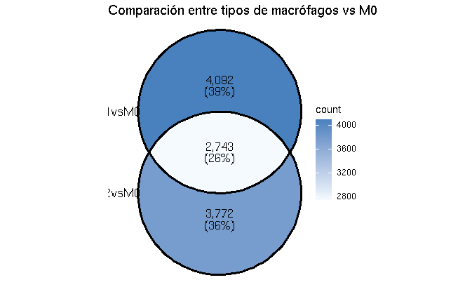

```r
if (!requireNamespace("ggVennDiagram", quietly = TRUE)) install.packages("ggVennDiagram")
library(ggVennDiagram)

genes_m2 <- rownames(subset(m2vsmo, padj < 0.05 & !is.na(padj)))
genes_m1 <- rownames(subset(m1vsmo, padj < 0.05 & !is.na(padj)))

venn_plot <- ggVennDiagram(list(M2vsM0 = genes_m2, M1vsM0 = genes_m1)) +
  scale_fill_gradient(low = "#F4FAFE", high = "#4981BF") +
  labs(title = "Comparación entre tipos de macrófagos vs M0")

print(venn_plot)
```